# Haudelindude arvukuse trendid 2025

Meelis Leivits

2025-10-19

## Metoodika

Trendide hindamisel on kasutatud seireprogrammide andmeid, mida on täiendatud seireväliste andmestikega (peamiselt EELIS leiukoha vaatlused).

**Tabel.** Kasutatud seireprogrammid.

| Kood | Programm |
| --- | --- |
| PR0041 | Haudelindude kooslused (väikesed meresaared) |
| PR0315 | Haudelindude kooslused (mererannik) |
| PR0066 | Haudelindude kooslused (rannaniidud) |
| PR0101 | Haudelindude kooslused (madalsood ja rabad) |
| PR0155 | Haudelindude kooslused (siseveekogud) |
| PR0171 | Metsise mängude seire |
| PR0068 | Rohunepi seire |
| PR0070 | Rukkiräägu seire |
| PR0029 | Röövlinud |
| PR0069 | Rähniliste seire |
| PR0065 | Haudelinnustiku punktloendus |

Järvede haudelinnustiku seire andmeid on täiendatud ajalooliste järveloenduste andmebaasiga. Mererannikute haudelinnustiku seire andmeid on täiendatud Matsalu lahe põhjalalda ja lõunakalda ajalooliste loendusandmetega (kuni 2012).

Arvukusmudelite sobitamisel kasutati R 4.3.3 (R Core Team 2020) laiendust rtrim 2.3.0 (Bogaart, van der Loo, and Pannekoek 2024). Arvukusmudel ehk nn. TRIM-mudel võimaldab sõltuvalt andmete täielikkusest kolme võimalust, mille põhitüübid on mudel 1 (fikseeritud populatsioonid, ajaline varieeruvus puudub), mudel 2 (lineaarsed muutused käänupunktide vahel) ja mudel 3 (sõltumatud aasta-efektid iga käänupunkti puhul). Mudeli tüüp 1 vastab olukorrale, kus asurkondade arvukus varieerub, kuid ei muutu läbi aastate. Mudel 2 ehk nn lineaarne mudel eeldab, et asurkondade arvukuses esineb lineaarne trend, mille keerukuse määravad nn käänupunktid (*change points*). Kõige lihtsam, ehk käänupunktiga 1 (ehk esimesel loendusaastal) tähistab lineaarse kasvu/kahanemisega mudelit. Mudeli tüüp 3 (*time-effects model*) on kõige keerukam ning selle puhul on kõik aastad arvestatud käänupunktideks.

Mudelite sobitamine on sooritatud keerukamast lihtsamale. Alustatud on mudeli tüübiga 3. Mittesobitumisel on seda lihtsustatud, eemaldadaes käänupunktidest aastad, kust vaatlusi ei ole või koguarvukus osutus nulliks (mudeli tüüp 2 käänupunktidega). Selle mudeli mittesobitumise puhul prooviti mudeli tüüpi 2 ilma käänupunktideta ehk kõige lihtsamat lineaarset mudelit. Viimase mittesobitumisel prooviti mudeli tüüpi 1.

Mitmebiotoopsete liikide osas on arvutused esitatud programmide (koosluste) kaupa eraldi. Iga koosluse arvukusmudeli põhjal on koostatud nn sulandatud mudel, kus iga mudel omab kaalu, mis skaleerib koosluse viimase kuue aasta üldarvukuse (*time totals*) vastavalt viimasele arvukushinnangule koosluses.

Näide. Suurkoovitaja viimane arvukushinanng on 600-900 paari. Kultuurmaadel pesitseb sellest ca 250 paari (keskmiselt 33%), soodes ca 500 paari (keskmiselt 67%), rannaniitudel ca 25 paari (keskmiselt 3,3%). Koosluse kaal saadakse koosluse arvukushinnangu jagamisel seiratava asurkonna suurusega.

**Tabel.** Koosluse arvukusmudelite kaalud suurkoovitaja näitel.

| Kooslus | Arvukushinanng | Seiratav asurkond | Kaal |
| --- | --- | --- | --- |
| Kultuurmaad (PR0065) | 250 | 22,8 | 11,0 |
| Rannaniidud (PR0066) | 25 | 23,5 | 1,1 |
| Sood (PR0101) | 500 | 400,0 | 1,2 |

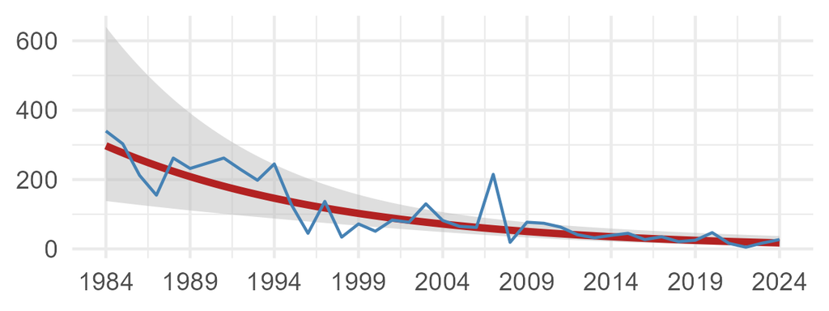

Suurkoovitaja arvukus ja trend kultuurmaadel (PR0065).

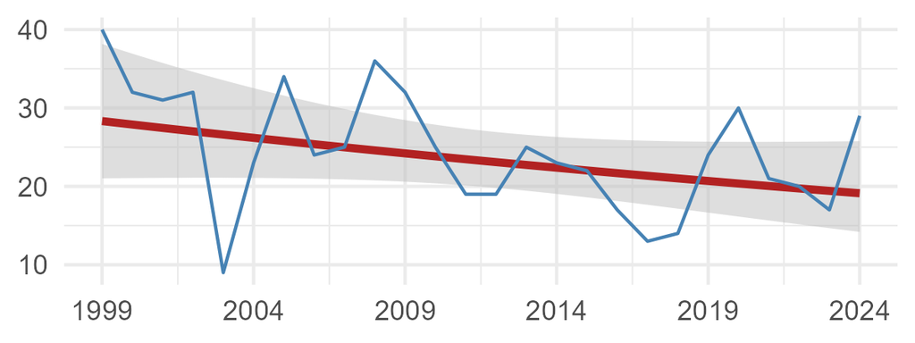

Suurkoovitaja arvukus ja trend rannaniitudel (PR0066).

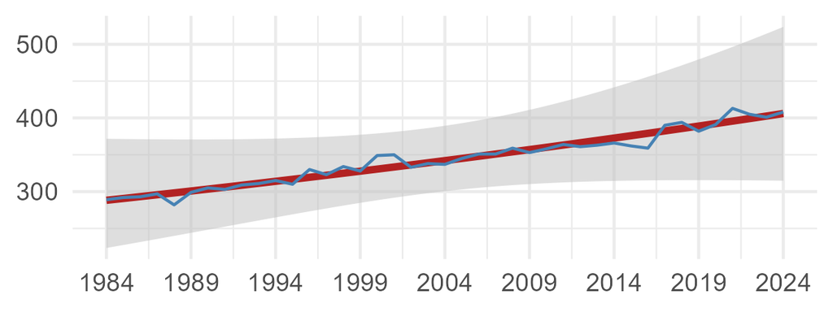

Suurkoovitaja arvukus ja trend soodes (PR0101).

Koosluste arvukusmudelite aastaste üldarvukuste (*time totals*) ning eeltoodud viisil hinnatud kaaludest koostatakse uus andmestik, millele sobitatakse uus arvukusmudel.

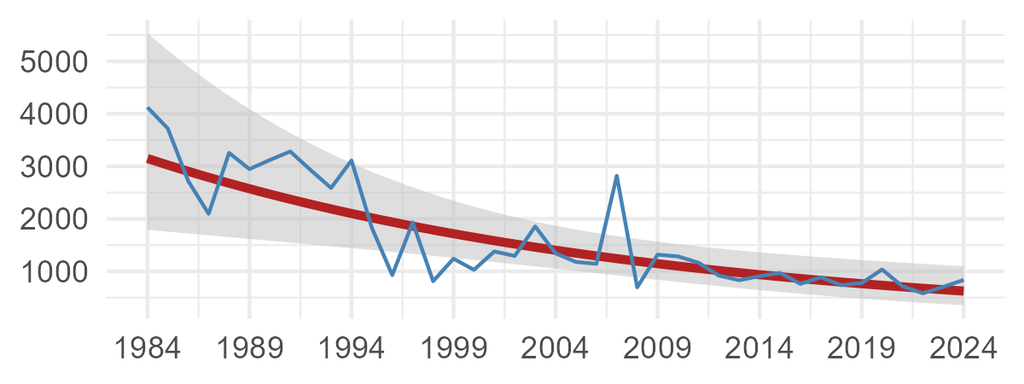

Suurkoovitaja arvukus ja trend Eestis (sulandatud arvukusmudelite põhjal).

## Tulemused

### Seireprogrammide pika perioodi (al 1980) ehk LT trendid

**Tabel.** Haudelindude arvukuse trendid pika-ajalisel (LT) perioodil (alates 1980 või vastavalt seireprogrammi algusele) seireprogrammide (skeem) andmete põhjal.

| EURING | Liik | Skeem¹ | Alates² | N³ | LT tõusukordaja (CV%)⁴ | LT %/a⁵ | LT muutuse %⁶ | LT trendiklass |
| --- | --- | --- | --- | --- | --- | --- | --- | --- |
| 90 | tuttpütt *Podiceps cristatus* | PR0041 | 1980 | 139 | 1,082(0,9) | 8,2 (6,3..10,0) | 3300 (1461..7208) | tugev kasv |
| 90 | tuttpütt *Podiceps cristatus* | PR0155 | 1983 | 15 | 1,017(0,6) | 1,7 (0,4..3,0) | 102 ( 19..241) | mõõdukas kasv |
| 1520 | kühmnokk-luik *Cygnus olor* | PR0041 | 1980 | 422 | 1,078(0,3) | 7,8 (7,2..8,4) | 2850 (2231..3628) | tugev kasv |
| 1520 | kühmnokk-luik *Cygnus olor* | PR0066 | 1999 | 24 | 0,994(4,0) | -0,6 (-8,3..7,2) | -14 (-89..506) | ebaselge |
| 1520 | kühmnokk-luik *Cygnus olor* | PR0155 | 1983 | 18 | 1,061(0,7) | 6,1 (4,8..7,5) | 1122 (605..2002) | mõõdukas kasv |
| 1540 | laululuik *Cygnus cygnus* | PR0101 | 1980 | 41 | 1,074(1,4) | 7,4 (4,4..10,5) | 2425 (596..8736) | mõõdukas kasv |
| 1540 | laululuik *Cygnus cygnus* | PR0155 | 1983 | 14 | 1,108(1,3) | 10,8 (8,1..13,6) | 7425 (2514..21011) | tugev kasv |
| 1610 | hallhani (roohani) *Anser anser* | PR0041 | 1980 | 206 | 0,977(0,2) | -2,3 (-2,7..-2,0) | -65 (-70..-59) | mõõdukas langus |
| 1610 | hallhani (roohani) *Anser anser* | PR0066 | 1999 | 17 | 1,000(0,2) | 0,0 (-0,5..0,5) | 0,1 (-12.. 14) | stabiilne |
| 1610 | hallhani (roohani) *Anser anser* | PR0155 | 1983 | 5 | 1,088(3,2) | 8,8 (2,0..15,7) | 3421 (132..45228) | mõõdukas kasv |
| 1730 | ristpart *Tadorna tadorna* | PR0041 | 1980 | 84 | 0,993(0,5) | -0,7 (-1,7..0,2) | -28 (-53..9,5) | stabiilne |
| 1730 | ristpart *Tadorna tadorna* | PR0066 | 1999 | 26 | 0,983(0,3) | -1,7 (-2,2..-1,1) | -36 (-45..-25) | mõõdukas langus |
| 1730 | ristpart *Tadorna tadorna* | PR0315 | 1982 | 7 | 0,958(1,3) | -4,2 (-6,7..-1,7) | -84 (-95..-53) | mõõdukas langus |
| 1820 | rääkspart *Mareca strepera* | PR0041 | 1980 | 286 | 1,182(2,3) | 18,2 (12,9..23,5) | 187167 (23804..1340637) | tugev kasv |
| 1820 | rääkspart *Mareca strepera* | PR0066 | 1999 | 41 | 1,017(1,6) | 1,7 (-1,4..4,9) | 57 (-30..245) | ebaselge |
| 1820 | rääkspart *Mareca strepera* | PR0155 | 1983 | 9 | 1,121(1,8) | 12,1 (8,2..16,0) | 12159 (2666..51533) | tugev kasv |
| 1820 | rääkspart *Mareca strepera* | PR0315 | 1982 | 10 | 1,061(1,4) | 6,1 (3,2..9,1) | 1197 (284..4137) | mõõdukas kasv |
| 1840 | piilpart *Anas crecca* | PR0041 | 1980 | 23 | 1,019(1,7) | 1,9 (-1,6..5,3) | 129 (-51..914) | ebaselge |
| 1840 | piilpart *Anas crecca* | PR0101 | 1980 | 118 | 1,011(0,4) | 1,1 (0,2..2,0) | 65 ( 11..145) | mõõdukas kasv |
| 1840 | piilpart *Anas crecca* | PR0155 | 1983 | 20 | 1,012(1,2) | 1,2 (-1,2..3,7) | 68 (-41..362) | stabiilne |
| 1860 | sinikael-part *Anas platyrhynchos* | PR0041 | 1980 | 291 | 1,037(0,2) | 3,7 (3,3..4,1) | 405 (325..500) | mõõdukas kasv |
| 1860 | sinikael-part *Anas platyrhynchos* | PR0066 | 1999 | 42 | 0,979(1,9) | -2,1 (-5,6..1,5) | -42 (-78.. 47) | ebaselge |
| 1860 | sinikael-part *Anas platyrhynchos* | PR0101 | 1980 | 164 | 1,030(0,5) | 3,0 (2,0..4,0) | 282 (148..485) | mõõdukas kasv |
| 1860 | sinikael-part *Anas platyrhynchos* | PR0155 | 1983 | 22 | 1,017(0,7) | 1,7 (0,3..3,2) | 106 ( 11..279) | mõõdukas kasv |
| 1860 | sinikael-part *Anas platyrhynchos* | PR0315 | 1982 | 11 | 0,999(0,8) | -0,1 (-1,7..1,6) | -2,8 (-52.. 94) | stabiilne |
| 1910 | rägapart *Spatula querquedula* | PR0041 | 1980 | 39 | 1,056(1,6) | 5,6 (2,3..9,0) | 1072 (176..4657) | mõõdukas kasv |
| 1910 | rägapart *Spatula querquedula* | PR0066 | 1999 | 33 | 0,953(2,2) | -4,7 (-8,7..-0,6) | -71 (-91..-15) | mõõdukas langus |
| 1910 | rägapart *Spatula querquedula* | PR0155 | 1983 | 11 | 0,991(1,3) | -0,9 (-3,4..1,6) | -33 (-77.. 92) | stabiilne |
| 1910 | rägapart *Spatula querquedula* | PR0315 | 1982 | 11 | 0,995(0,9) | -0,5 (-2,3..1,3) | -18 (-63.. 77) | stabiilne |
| 1940 | luitsnokk-part *Spatula clypeata* | PR0041 | 1980 | 151 | 1,023(0,3) | 2,3 (1,7..3,0) | 180 (110..273) | mõõdukas kasv |

[output cut: 103 more lines]

Veeru päiste seletus:  
<sup>1</sup> Seireprogram, vt. metoodika;  
<sup>2</sup> Andmete perioodi algus;  
<sup>3</sup> Seirealade arv;  
<sup>4</sup> Log-lineaarse trendijoone tõusukordaja, keskväärtus ja sulgudes CV protsendina;  
<sup>5</sup> Aastane muutus protsentides, vastavalt tõusukordajale;  
<sup>6</sup> Absolutne muutus protsendina vastavalt tõusukordajale ja perioodi pikkusele.

#### Kokku sulandatud ehk komposiittrendid

Järgnevalt on mitmebiotoopsete liikide puhul teostatud arvukusmudelite kokkusulandamine, arvestades seiratava asurkonna suurust ning ligikaudset arvukushinnangut koosluses.

**Tabel.** Mitmebiotoopsete liikide sulandatud arvukuse trendid pika-ajalisel (LT) perioodil (alates 1980 või vastavalt seireprogrammi algusele).

| EURING | Liik | Alates² | N³ | LT tõusukordaja (CV%)⁴ | LT %/a⁵ | LT muutuse %⁶ | LT trendiklass | Indeks |
| --- | --- | --- | --- | --- | --- | --- | --- | --- |
| 1520 | kühmnokk-luik *Cygnus olor* | 1980 | 3 | 1,074(0,2) | 7,4 (7,0..7,9) | 2434 (1966..3006) | tugev kasv |  |
| 1610 | hallhani (roohani) *Anser anser* | 1980 | 2 | 0,977(0,2) | -2,3 (-2,6..-2,0) | -65 (-70..-60) | mõõdukas langus |  |
| 1730 | ristpart *Tadorna tadorna* | 1980 | 3 | 0,960(1,1) | -4,0 (-6,0..-1,9) | -84 (-94..-59) | mõõdukas langus |  |
| 1820 | rääkspart *Mareca strepera* | 1981 | 4 | 1,097(1,0) | 9,7 (7,5..11,9) | 5826 (2359..13938) | tugev kasv |  |
| 1840 | piilpart *Anas crecca* | 1980 | 3 | 1,006(0,5) | 0,6 (-0,3..1,6) | 32 (-14..101) | stabiilne |  |
| 1860 | sinikael-part *Anas platyrhynchos* | 1980 | 5 | 0,992(0,5) | -0,8 (-1,8..0,3) | -29 (-56.. 13) | stabiilne |  |
| 1910 | rägapart *Spatula querquedula* | 1981 | 4 | 0,997(0,6) | -0,3 (-1,6..0,9) | -14 (-51.. 50) | stabiilne |  |
| 1940 | luitsnokk-part *Spatula clypeata* | 1980 | 4 | 0,992(0,5) | -0,8 (-1,7..0,2) | -29 (-54..7,6) | stabiilne |  |
| 2030 | tuttvart *Aythya fuligula* | 1980 | 3 | 0,969(0,4) | -3,1 (-3,8..-2,4) | -76 (-83..-66) | mõõdukas langus |  |
| 2180 | sõtkas *Bucephala clangula* | 1980 | 3 | 1,031(0,3) | 3,1 (2,4..3,7) | 289 (192..418) | mõõdukas kasv |  |
| 2230 | jääkoskel *Mergus merganser* | 1980 | 4 | 0,974(0,9) | -2,6 (-4,4..-0,8) | -69 (-87..-29) | mõõdukas langus |  |
| 4290 | lauk *Fulica atra* | 1983 | 2 | 0,971(0,6) | -2,9 (-4,0..-1,8) | -71 (-82..-53) | mõõdukas langus |  |
| 4560 | naaskelnokk (harilik naaskelnokk) *Recurvirostra avosetta* | 1980 | 2 | 1,025(0,7) | 2,5 (1,0..3,9) | 200 ( 60..457) | mõõdukas kasv |  |
| 4700 | liivatüll *Charadrius hiaticula* | 1980 | 3 | 0,987(0,4) | -1,3 (-2,1..-0,6) | -45 (-62..-23) | mõõdukas langus |  |
| 4930 | kiivitaja (harilik kiivitaja) *Vanellus vanellus* | 1980 | 5 | 1,038(0,6) | 3,8 (2,5..5,1) | 442 (207..848) | mõõdukas kasv |  |
| 5123 | niidurüdi *Calidris alpina schinzii* | 1982 | 3 | 0,991(0,6) | -0,9 (-2,0..0,2) | -32 (-58.. 9) | stabiilne |  |
| 5190 | tikutaja (taevasikk) *Gallinago gallinago* | 1980 | 3 | 0,989(1,0) | -1,1 (-2,9..0,8) | -38 (-74.. 43) | stabiilne |  |
| 5320 | mustsaba-vigle *Limosa limosa* | 1989 | 2 | 1,038(1,3) | 3,8 (1,1..6,4) | 277 ( 47..847) | mõõdukas kasv |  |
| 5410 | suurkoovitaja *Numenius arquata* | 1984 | 3 | 0,960(1,2) | -4,0 (-6,2..-1,7) | -81 (-93..-51) | mõõdukas langus |  |
| 5460 | punajalg-tilder *Tringa totanus* | 1982 | 4 | 0,998(0,3) | -0,2 (-0,7..0,4) | -7,1 (-26.. 16) | stabiilne |  |
| 5780 | väikekajakas *Hydrocoloeus minutus* | 1982 | 2 | 1,012(0,9) | 1,2 (-0,5..3,0) | 70 (-20..256) | stabiilne |  |
| 5820 | naerukajakas *Chroicocephalus ridibundus* | 1983 | 2 | 0,992(0,7) | -0,8 (-2,2..0,5) | -30 (-60.. 24) | stabiilne |  |
| 5900 | kalakajakas *Larus canus* | 1982 | 4 | 0,959(0,5) | -4,1 (-5,1..-3,2) | -84 (-89..-75) | mõõdukas langus |  |
| 6150 | jõgitiir *Sterna hirundo* | 1980 | 4 | 1,042(0,4) | 4,2 (3,3..5,1) | 532 (331..822) | mõõdukas kasv |  |
| 9760 | põldlõoke *Alauda arvensis* | 1980 | 3 | 1,043(0,4) | 4,3 (3,6..5,0) | 567 (388..810) | mõõdukas kasv |  |

Veeru päiste seletus:  
<sup>1</sup> Andmete perioodi algus;  
<sup>2</sup> Programmide arv;  
<sup>3</sup> Log-lineaarse trendijoone tõusukordaja, keskväärtus ja sulgudes CV protsendina;  
<sup>4</sup> Aastane muutus protsentides, vastavalt tõusukordajale;  
<sup>5</sup> Absolutne muutus protsendina vastavalt tõusukordajale ja perioodi pikkusele.

**Tabel.** Mitmebiotoopsete liikide sulandatud arvukuse trendid lühiajalisel (ST) perioodil (2013-2024).

| EURING | Liik | Alates² | N³ | ST tõusukordaja (CV%)⁴ | ST %/a⁵ | ST muutuse %⁶ | ST trendiklass | Indeks |
| --- | --- | --- | --- | --- | --- | --- | --- | --- |
| 1520 | kühmnokk-luik *Cygnus olor* | 2013 | 3 | 1,029(1,6) | 2,9 (-0,3..6,1) | 41 (-3,9..104) | ebaselge |  |
| 1610 | hallhani (roohani) *Anser anser* | 2013 | 2 | 1,029(1,1) | 2,9 (0,7..5,1) | 40 (8,2.. 81) | mõõdukas kasv |  |
| 1730 | ristpart *Tadorna tadorna* | 2013 | 3 | 0,964(1,1) | -3,6 (-5,7..-1,6) | -36 (-50..-18) | mõõdukas langus |  |
| 1820 | rääkspart *Mareca strepera* | 2013 | 4 | 1,119(1,8) | 11,9 (7,9..15,9) | 286 (150..489) | tugev kasv |  |
| 1840 | piilpart *Anas crecca* | 2013 | 3 | 1,030(3,1) | 3,0 (-3,3..9,4) | 43 (-33..193) | ebaselge |  |
| 1860 | sinikael-part *Anas platyrhynchos* | 2013 | 5 | 0,974(1,7) | -2,6 (-5,8..0,6) | -27 (-51..7,2) | ebaselge |  |
| 1910 | rägapart *Spatula querquedula* | 2013 | 4 | 0,968(1,7) | -3,2 (-6,4..0,0) | -32 (-55..0,55) | ebaselge |  |
| 1940 | luitsnokk-part *Spatula clypeata* | 2013 | 4 | 0,943(5,3) | -5,7 (-15,4..4,1) | -50 (-87.. 62) | ebaselge |  |
| 2030 | tuttvart *Aythya fuligula* | 2013 | 3 | 0,973(3,9) | -2,7 (-10,2..4,8) | -28 (-73.. 75) | ebaselge |  |
| 2180 | sõtkas *Bucephala clangula* | 2013 | 3 | 1,057(1,5) | 5,7 (2,7..8,7) | 94 ( 37..173) | mõõdukas kasv |  |
| 2230 | jääkoskel *Mergus merganser* | 2013 | 4 | 0,986(0,8) | -1,4 (-2,9..0,2) | -15 (-30..1,9) | stabiilne |  |
| 4290 | lauk *Fulica atra* | 2013 | 2 | 1,066(2,8) | 6,6 (0,9..12,4) | 116 ( 11..306) | mõõdukas kasv |  |
| 4560 | naaskelnokk (harilik naaskelnokk) *Recurvirostra avosetta* | 2013 | 2 | 1,063(2,2) | 6,3 (1,7..10,9) | 108 ( 22..246) | mõõdukas kasv |  |
| 4700 | liivatüll *Charadrius hiaticula* | 2013 | 3 | 0,980(0,4) | -2,0 (-2,8..-1,2) | -22 (-29..-14) | mõõdukas langus |  |
| 4930 | kiivitaja (harilik kiivitaja) *Vanellus vanellus* | 2013 | 5 | 0,954(1,1) | -4,6 (-6,7..-2,4) | -43 (-57..-26) | mõõdukas langus |  |
| 5123 | niidurüdi *Calidris alpina schinzii* | 2013 | 3 | 1,013(1,5) | 1,3 (-1,7..4,2) | 16 (-18.. 64) | stabiilne |  |
| 5190 | tikutaja (taevasikk) *Gallinago gallinago* | 2013 | 3 | 0,944(2,6) | -5,6 (-10,3..-0,8) | -50 (-73..-9,4) | mõõdukas langus |  |
| 5320 | mustsaba-vigle *Limosa limosa* | 2013 | 2 | 1,052(2,5) | 5,2 (0,1..10,3) | 84 (1,5..223) | ebaselge |  |
| 5410 | suurkoovitaja *Numenius arquata* | 2013 | 3 | 0,981(1,3) | -1,9 (-4,5..0,6) | -21 (-42..7,7) | stabiilne |  |
| 5460 | punajalg-tilder *Tringa totanus* | 2013 | 4 | 1,001(0,3) | 0,1 (-0,6..0,7) | 0,66 (-6,8..8,6) | stabiilne |  |
| 5780 | väikekajakas *Hydrocoloeus minutus* | 2013 | 2 | 0,979(2,3) | -2,1 (-6,4..2,3) | -22 (-55.. 31) | ebaselge |  |
| 5820 | naerukajakas *Chroicocephalus ridibundus* | 2013 | 2 | 1,132(0,9) | 13,2 (11,2..15,2) | 343 (257..448) | tugev kasv |  |
| 5900 | kalakajakas *Larus canus* | 2013 | 4 | 1,008(0,6) | 0,8 (-0,4..2,0) | 9,9 ( -5.. 27) | stabiilne |  |
| 6150 | jõgitiir *Sterna hirundo* | 2013 | 4 | 1,075(0,9) | 7,5 (5,7..9,3) | 138 ( 94..191) | tugev kasv |  |
| 9760 | põldlõoke *Alauda arvensis* | 2013 | 3 | 1,000(1,3) | 0,0 (-2,4..2,5) | 0,59 (-26.. 35) | stabiilne |  |

Veeru päiste seletus:  
<sup>1</sup> Andmete perioodi algus;  
<sup>2</sup> Programmide arv;  
<sup>3</sup> Log-lineaarse trendijoone tõusukordaja, keskväärtus ja sulgudes CV protsendina;  
<sup>4</sup> Aastane muutus protsentides, vastavalt tõusukordajale;  
<sup>5</sup> Absolutne muutus protsendina vastavalt tõusukordajale ja perioodi pikkusele.

### Pika perioodi (al 1980) ehk LT (*long term*) trendid

**Tabel.** Haudelindude arvukuse trendid pika-ajalisel (LT) perioodil (alates 1980 või vastavalt seireprogrammi algusele) erinevate seireprogrammide (skeem) andmete põhjal.

| EURING | Liik | Skeem¹ | Alates² | N³ | LT tõusukordaja (CV%)⁴ | LT %/a⁵ | LT muutuse %⁶ | LT trendiklass |
| --- | --- | --- | --- | --- | --- | --- | --- | --- |
| 1670 | valgepõsk-lagle *Branta leucopsis* | PR0041 | 1981 | 46 | 1,043 (1,1) | 4,3 (2,1..6,5) | 534 (147..1492) | mõõdukas kasv |
| 1610 | hallhani (roohani) *Anser anser* | PR0041 | 1980 | 145 | 0,977 (0,2) | -2,3 (-2,6..-2,0) | -65 (-70..-59) | mõõdukas langus |
| 1520 | kühmnokk-luik *Cygnus olor* | PR0041 | 1980 | 313 | 1,078 (0,3) | 7,8 (7,2..8,4) | 2845 (2225..3626) | tugev kasv |
| 1540 | laululuik *Cygnus cygnus* | PR0155, PR0101 | 1996 | 19 | 1,094 (1,2) | 9,4 (6,7..12,0) | 1239 (561..2567) | tugev kasv |
| 1730 | ristpart *Tadorna tadorna* | PR0041, PR0066, PR0315 | 1980 | 78 | 0,981 (0,4) | -1,9 (-2,7..-1,1) | -57 (-70..-38) | mõõdukas langus |
| 1910 | rägapart *Spatula querquedula* | PR0155, PR0041, PR0066, PR0315 | 1981 | 61 | 1,005 (0,7) | 0,5 (-0,8..1,9) | 27 (-29..125) | stabiilne |
| 1940 | luitsnokk-part *Spatula clypeata* | PR0155, PR0041, PR0066, PR0315 | 1980 | 142 | 1,012 (0,3) | 1,2 (0,6..1,8) | 69 ( 30..120) | mõõdukas kasv |
| 1820 | rääkspart *Mareca strepera* | PR0041 | 1981 | 193 | 1,177 (2,2) | 17,7 (12,6..22,9) | 132373 (18153..882577) | tugev kasv |
| 1860 | sinikael-part *Anas platyrhynchos* | PR0065 | 1984 | 52 | 0,978 (0,9) | -2,2 (-4,0..-0,3) | -59 (-81..-13) | mõõdukas langus |
| 1840 | piilpart *Anas crecca* | PR0155, PR0101 | 1994 | 69 | 1,025 (0,7) | 2,5 (1,1..3,9) | 113 ( 39..225) | mõõdukas kasv |
| 1980 | punapea-vart *Aythya ferina* | PR0155 | 1983 | 8 | 0,958 (1,3) | -4,2 (-6,7..-1,8) | -84 (-95..-53) | mõõdukas langus |
| 2030 | tuttvart *Aythya fuligula* | PR0155, PR0101, PR0041, PR0066 | 1980 | 243 | 1,025 (0,3) | 2,5 (1,9..3,1) | 203 (131..296) | mõõdukas kasv |
| 2060 | hahk (harilik hahk) *Somateria mollissima* | PR0041 | 1980 | 171 | 0,919 (0,2) | -8,1 (-8,4..-7,7) | -98 (-98..-97) | tugev langus |
| 2150 | tõmmuvaeras *Melanitta fusca* | PR0041 | 1980 | 59 | 0,942 (0,5) | -5,8 (-6,8..-4,8) | -93 (-96..-89) | mõõdukas langus |
| 2180 | sõtkas *Bucephala clangula* | PR0155, PR0101, PR0041 | 1980 | 92 | 1,037 (0,6) | 3,7 (2,4..5,0) | 415 (193..801) | mõõdukas kasv |
| 2230 | jääkoskel *Mergus merganser* | PR0155, PR0041, PR0066 | 1980 | 125 | 0,985 (0,2) | -1,5 (-1,9..-1,0) | -49 (-59..-37) | mõõdukas langus |
| 2210 | rohukoskel *Mergus serrator* | PR0041 | 1980 | 100 | 1,007 (0,3) | 0,7 (0,2..1,3) | 40 (9,7.. 77) | mõõdukas kasv |
| 3260 | laanepüü *Tetrastes bonasia* | PR0065 | 1984 | 23 | 0,934 (2,8) | -6,6 (-11,8..-1,5) | -94 (-99..-46) | mõõdukas langus |
| 3350 | metsis (mõtus) *Tetrao urogallus* | PR0171 | 1980 | 546 | 0,983 (0,2) | -1,7 (-2,1..-1,3) | -54 (-61..-46) | mõõdukas langus |
| 7950 | piiritaja (piirpääsuke) *Apus apus* | PR0065 | 1985 | 64 | 0,997 (0,5) | -0,3 (-1,3..0,7) | -12 (-41.. 31) | stabiilne |
| 7240 | kägu (harilik kägu) *Cuculus canorus* | PR0065 | 1984 | 164 | 1,016 (0,3) | 1,6 (1,1..2,2) | 95 ( 54..146) | mõõdukas kasv |
| 6650 | kodutuvi *Columba livia* | PR0065 | 2002 | 25 | 0,983 (1,2) | -1,7 (-4,1..0,7) | -32 (-62.. 17) | stabiilne |
| 6680 | õõnetuvi *Columba oenas* | PR0065 | 1985 | 12 | 1,002 (2,1) | 0,2 (-4,0..4,4) | 7,5 (-80..450) | stabiilne |
| 6700 | kaelustuvi (meigas) *Columba palumbus* | PR0065 | 1984 | 152 | 1,021 (0,4) | 2,1 (1,3..2,8) | 132 ( 71..215) | mõõdukas kasv |
| 6870 | turteltuvi (harilik turteltuvi) *Streptopelia turtur* | PR0065 | 1984 | 46 | 0,920 (1,9) | -8,0 (-11,3..-4,6) | -97 (-99..-85) | mõõdukas langus |
| 4070 | rooruik *Rallus aquaticus* | PR0155 | 1983 | 8 | 1,022 (1,0) | 2,2 (0,3..4,2) | 151 ( 11..458) | mõõdukas kasv |
| 4210 | rukkirääk *Crex crex* | PR0070 | 2002 | 15 | 0,942 (0,7) | -5,8 (-7,1..-4,5) | -75 (-82..-65) | mõõdukas langus |
| 4080 | täpikhuik *Porzana porzana* | PR0155 | 1987 | 6 | 0,939 (1,8) | -6,1 (-9,5..-2,7) | -91 (-98..-65) | mõõdukas langus |
| 4290 | lauk *Fulica atra* | PR0155 | 1996 | 11 | 0,979 (0,9) | -2,1 (-3,9..-0,4) | -47 (-69..-10) | mõõdukas langus |
| 4330 | sookurg *Grus grus* | PR0065 | 1984 | 78 | 1,063 (0,9) | 6,3 (4,3..8,2) | 1106 (459..2466) | mõõdukas kasv |

[output cut: 135 more lines]

Veeru päiste seletus:  
<sup>1</sup> Seireprogrammid, mille andmed on arvukusmudeli sobitusel kasutatud;  
<sup>2</sup> Andmete perioodi algus, vaikimisi 1980, või esimene positiivse loendustulemusega aasta (nulli ei ole võimalik baasina kasutada);  
<sup>3</sup> Seirealade arv;  
<sup>4</sup> Log-lineaarse trendijoone tõusukordaja, keskväärtus ja sulgudes CV protsendina;  
<sup>5</sup> Aastane muutus protsentides, vastavalt tõusukordajale;  
<sup>6</sup> Absolutne muutus protsendina vastavalt tõusukordajale ja perioodi pikkusele.

### Lühikese perioodi (2013-2024) ehk ST (*short term*) trendid

**Tabel.** Haudelindude arvukuse trendid lühi-ajalisel (ST) perioodil (alates 2013) erinevate seireprogrammide (skeem) andmete põhjal.

| EURING | Liik | Skeem¹ | Alates² | N³ | ST tõusukordaja (CV%)⁴ | ST %/a⁵ | ST muutuse %⁶ | ST trendiklass | Indeks |
| --- | --- | --- | --- | --- | --- | --- | --- | --- | --- |
| 1670 | valgepõsk-lagle *Branta leucopsis* | PR0041 | 2013 | 37 | 1,008 (1,5) | 0,8 (-2,1..3,8) | 10 (-23.. 57) | stabiilne |  |
| 1610 | hallhani (roohani) *Anser anser* | PR0041 | 2013 | 123 | 1,068 (1,0) | 6,8 (4,7..9,0) | 121 ( 73..181) | mõõdukas kasv |  |
| 1520 | kühmnokk-luik *Cygnus olor* | PR0041 | 2013 | 292 | 1,040 (0,4) | 4,0 (3,1..4,8) | 59 ( 44.. 76) | mõõdukas kasv |  |
| 1540 | laululuik *Cygnus cygnus* | PR0155, PR0101 | 2013 | 17 | 1,114 (4,6) | 11,4 (1,4..21,5) | 267 ( 18..936) | mõõdukas kasv |  |
| 1730 | ristpart *Tadorna tadorna* | PR0041, PR0066, PR0315 | 2013 | 52 | 1,003 (2,2) | 0,3 (-4,1..4,6) | 3,3 (-39.. 72) | ebaselge |  |
| 1910 | rägapart *Spatula querquedula* | PR0155, PR0041, PR0066, PR0315 | 2013 | 39 | 1,016 (3,1) | 1,6 (-4,5..7,7) | 21 (-42..143) | ebaselge |  |
| 1940 | luitsnokk-part *Spatula clypeata* | PR0155, PR0041, PR0066, PR0315 | 2013 | 116 | 0,985 (1,2) | -1,5 (-3,9..0,8) | -17 (-38..9,9) | stabiilne |  |
| 1820 | rääkspart *Mareca strepera* | PR0041 | 2013 | 182 | 1,076 (0,9) | 7,6 (5,8..9,5) | 142 ( 97..196) | tugev kasv |  |
| 1790 | viupart *Mareca penelope* |  | 2013 | 6 | 0,871 (7,9) | -12,9 (-26,3..0,6) | -81 (-97.. 7) | ebaselge |  |
| 1860 | sinikael-part *Anas platyrhynchos* | PR0065 | 2013 | 35 | 0,972 (1,9) | -2,8 (-6,4..0,8) | -28 (-55.. 11) | ebaselge |  |
| 1840 | piilpart *Anas crecca* | PR0155, PR0101 | 2013 | 63 | 1,024 (3,0) | 2,4 (-3,6..8,4) | 33 (-35..164) | ebaselge |  |
| 1980 | punapea-vart *Aythya ferina* | PR0155 | 2014 | 7 | 1,006 (4,3) | 0,6 (-7,9..9,0) | 6,4 (-59..158) | ebaselge |  |
| 2030 | tuttvart *Aythya fuligula* | PR0155, PR0101, PR0041, PR0066 | 2013 | 211 | 1,001 (0,9) | 0,1 (-1,6..1,9) | 1,6 (-18.. 25) | stabiilne |  |
| 2060 | hahk (harilik hahk) *Somateria mollissima* | PR0041 | 2013 | 136 | 0,985 (0,7) | -1,5 (-2,8..-0,1) | -16 (-29..-1,4) | stabiilne |  |
| 2150 | tõmmuvaeras *Melanitta fusca* | PR0041 | 2013 | 36 | 0,927 (3,5) | -7,3 (-13,7..-0,9) | -60 (-83..-11) | ebaselge |  |
| 2180 | sõtkas *Bucephala clangula* | PR0155, PR0101, PR0041 | 2013 | 91 | 1,017 (1,5) | 1,7 (-1,3..4,7) | 23 (-15.. 74) | ebaselge |  |
| 2230 | jääkoskel *Mergus merganser* | PR0155, PR0041, PR0066 | 2013 | 107 | 1,026 (1,3) | 2,6 (0,0..5,3) | 37 (0,42.. 85) | ebaselge |  |
| 2210 | rohukoskel *Mergus serrator* | PR0041 | 2013 | 87 | 1,001 (1,5) | 0,1 (-2,8..2,9) | 0,77 (-29.. 41) | stabiilne |  |
| 3260 | laanepüü *Tetrastes bonasia* | PR0065 | 2013 | 5 | 0,943 (6,8) | -5,7 (-18,2..6,8) | -51 (-91..120) | ebaselge |  |
| 3350 | metsis (mõtus) *Tetrao urogallus* | PR0171 | 2013 | 464 | 0,984 (0,7) | -1,6 (-2,9..-0,3) | -18 (-30..-3,7) | mõõdukas langus |  |
| 7950 | piiritaja (piirpääsuke) *Apus apus* | PR0065 | 2013 | 41 | 0,991 (1,2) | -0,9 (-3,3..1,5) | -11 (-33.. 19) | stabiilne |  |
| 7240 | kägu (harilik kägu) *Cuculus canorus* | PR0065 | 2013 | 90 | 0,996 (0,6) | -0,4 (-1,5..0,7) | -4,4 (-16..8,8) | stabiilne |  |
| 6650 | kodutuvi *Columba livia* | PR0065 | 2013 | 25 | 0,890 (2,3) | -11,0 (-15,0..-7,0) | -75 (-86..-58) | tugev langus |  |
| 6680 | õõnetuvi *Columba oenas* | PR0065 | 2013 | 11 | 1,312 (8,9) | 31,2 (8,4..54,1) | 2512 (163..17802) | tugev kasv |  |
| 6700 | kaelustuvi (meigas) *Columba palumbus* | PR0065 | 2013 | 88 | 1,052 (0,6) | 5,2 (4,0..6,4) | 84 ( 61..110) | mõõdukas kasv |  |
| 6870 | turteltuvi (harilik turteltuvi) *Streptopelia turtur* | PR0065 | 2013 | 12 | 0,905 (5,7) | -9,5 (-19,6..0,7) | -70 (-93..8,3) | ebaselge |  |
| 4070 | rooruik *Rallus aquaticus* | PR0155 | 2014 | 8 | 1,019 (3,7) | 1,9 (-5,4..9,3) | 23 (-46..165) | ebaselge |  |
| 4210 | rukkirääk *Crex crex* | PR0070 | 2013 | 15 | 0,934 (1,2) | -6,6 (-8,8..-4,4) | -56 (-67..-42) | mõõdukas langus |  |
| 4080 | täpikhuik *Porzana porzana* | PR0155 | 2014 | 4 | 0,837 (12,5) | -16,3 (-36,8..4,2) | -86 (-99.. 57) | ebaselge |  |
| 4290 | lauk *Fulica atra* | PR0155 | 2014 | 11 | 0,983 (2,5) | -1,7 (-6,4..3,1) | -17 (-52.. 40) | ebaselge |  |

[output cut: 135 more lines]

Veeru päiste seletus:  
<sup>1</sup> Seireprogrammid, mille andmed on arvukusmudeli sobitusel kasutatud;  
<sup>2</sup> Andmete perioodi algus, vaikimisi 2013, või esimene positiivse loendustulemusega aasta (nulli ei ole võimalik baasina kasutada);  
<sup>3</sup> Seirealade arv;  
<sup>4</sup> Log-lineaarse trendijoone tõusukordaja, keskväärtus ja sulgudes CV protsendina;  
<sup>5</sup> Aastane muutus protsentides, vastavalt tõusukordajale;  
<sup>6</sup> Absolutne muutus protsendina vastavalt tõusukordajale ja perioodi pikkusele.

## Kasutatud allikad

Bogaart, Patrick, Mark van der Loo, and Jeroen Pannekoek. 2024. *Rtrim: Trends and Indices for Monitoring Data*. https://CRAN.R-project.org/package=rtrim.

R Core Team. 2020. *R: A Language and Environment for Statistical Computing*. Vienna, Austria: R Foundation for Statistical Computing. https://www.R-project.org/.